# Sparcc Simulation 2

Anonymous

02/03/2025

```r
rm(list = ls())
library(dplyr)
library(tidyverse)
library(ggplot2)
library(ggh4x)
library(scales)
library(ggthemes)
library(kableExtra)
```

## Simulation Setup

The goal of this program is to evaluate the performance of the semiparametric efficient estimator $\widehat{\pmb{\beta}}_{sp}$ using simulations in the following setting:

- $Z \sim \textrm{Bernoulli}(0.5)$,
- $X|Z \sim \textrm{beta}(\alpha_1 + \alpha_2 Z, \alpha_3 + \alpha_4 Z)$,
- $C|Z \sim \textrm{beta}(\gamma_1 + \gamma_2 Z, \gamma_3 + \gamma_4 Z)$,
- $Y|X,Z \sim N(\beta_0 + \beta_1X + \beta_2Z, \sigma^2)$.

For all simulations, both nuisance distributions are correctly specified as beta.

For each simulation, we generate a data set of size $n$ then compute the complete case estimator $\widehat{\pmb{\beta}}_{cc}$, the oracle estimator $\widehat{\pmb{\beta}}_{or}$, the parametric MLE $\widehat{\pmb{\beta}}_{ml}$, and the semiparametric efficient estimator $\widehat{\pmb{\beta}}_{sp}$.

```r
# true beta
B <- c(1, 10, 2, log(1))

# load simulation results from each of 10 clusters
sim.out.list <- lapply(
  X = 0:9,
  FUN = function(clust) {
    cbind(clust,
          read.csv(paste0(
            "sim2_data/sd",
            clust, ".csv")))
  })

# combine simulation results into 1 data frame
sim.out <- bind_rows(sim.out.list)

colnames(sim.out) <- gsub(".B", "", colnames(sim.out))
colnames(sim.out) <- gsub("B2", "trueB2", colnames(sim.out))

# make long data frame
sim.out.long <- sim.out %>%
  pivot_longer(cols = starts_with("B"),
               names_to = "method.param",
               values_to = "estimate") %>%
    mutate(method = factor(substr(method.param, 2, 3),
                           levels = c("or", "cc", "ml", "sp"),
                           labels = c("Oracle",
                                      "Complete Case",
                                      "MLE",
                                      "SPARCC")),
           param = factor(substr(method.param, 4, 4)),
           B.true = B[param])
```

## Simulation Results

#### Errors in Simulations

We first look at which simulation settings lead to errors.

```r
# check for simulations with errors
sim.out.long %>%
  filter(param == 1) %>%
  group_by(n, q, method) %>%
  summarize(prop.error = mean(is.na(estimate))) %>%
  filter(prop.error > 0) %>%
  kable(digits = 3) %>%
  kable_styling("striped")
```

| n | q | method | prop.error |
| --- | --- | --- | --- |
| 200 | 0.40 | Oracle | 0.001 |
| 200 | 0.40 | Complete Case | 0.001 |
| 200 | 0.40 | MLE | 0.001 |
| 200 | 0.40 | SPARCC | 0.001 |
| 200 | 0.60 | Oracle | 0.001 |
| 200 | 0.65 | Oracle | 0.005 |
| 200 | 0.65 | Complete Case | 0.001 |
| 200 | 0.65 | MLE | 0.001 |
| 200 | 0.65 | SPARCC | 0.001 |
| 200 | 0.70 | Oracle | 0.003 |
| 200 | 0.70 | MLE | 0.006 |
| 200 | 0.75 | Oracle | 0.025 |
| 200 | 0.75 | MLE | 0.010 |
| 200 | 0.80 | Oracle | 0.074 |
| 200 | 0.80 | MLE | 0.028 |
| 200 | 0.80 | SPARCC | 0.005 |
| 200 | 0.85 | Oracle | 0.130 |
| 200 | 0.85 | Complete Case | 0.001 |
| 200 | 0.85 | MLE | 0.075 |
| 200 | 0.85 | SPARCC | 0.012 |
| 200 | 0.90 | Oracle | 0.285 |
| 200 | 0.90 | MLE | 0.114 |
| 200 | 0.90 | SPARCC | 0.049 |
| 800 | 0.85 | Oracle | 0.001 |
| 800 | 0.85 | MLE | 0.004 |
| 800 | 0.90 | Oracle | 0.019 |
| 800 | 0.90 | MLE | 0.011 |
| 800 | 0.90 | SPARCC | 0.001 |
| 8000 | 0.65 | Oracle | 0.001 |
| 8000 | 0.65 | Complete Case | 0.001 |
| 8000 | 0.65 | MLE | 0.001 |
| 8000 | 0.65 | SPARCC | 0.001 |

```r
# extract simulation parameters
n <- unique(sim.out$n)
q <- unique(sim.out$q)
n.rep <- nrow(sim.out) /
  n_distinct(dplyr::select(sim.out, n, q))

# make labels for plots
param.labs <- c("\u03B20", "\u03B21", "\u03B22", "log\u03C3\u00B2")
names(param.labs) <- 1:4

# colorblind friendly pallette
pal_light <- c('#EE6677', '#228833', '#4477AA', '#CCBB44', '#66CCEE', '#AA3377', '#BBBBBB')
pal_dark <- c('#991122', '#114419', '#223b55', '#6b611d', '#117799', '#55193b', '#5d5d5d')
```

```r
# obtain empirical variances by method, parameter, and q
sim.out.sum <- sim.out.long %>%
  group_by(n, q, method, param) %>%
  filter(!is.na(estimate)) %>%
  summarise(var = var(estimate),
            Var = mean((estimate - B.true) ^ 2),
            se.Var = sd((estimate - B.true) ^ 2) / sqrt(n.rep),
            Var.lower = Var - qnorm(0.975) * se.Var ,
            Var.upper = Var + qnorm(0.975) * se.Var)
```

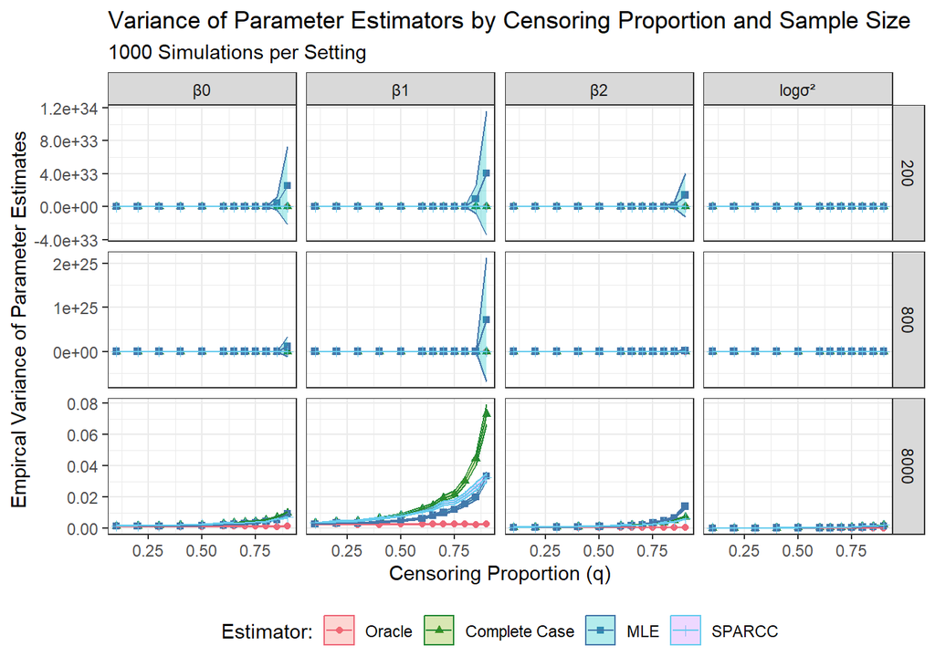

```r
# plot variance over q
ggplot(sim.out.sum,
       aes(x = q,
           y = Var,
           ymin = Var.lower,
           ymax = Var.upper,
           fill = method,
           color = method,
           shape = method)) +
  geom_point() +
  geom_ribbon(alpha = 0.3) +
  geom_line() +
  facet_grid(n ~ param,
             scales = "free",
             labeller = labeller(param = param.labs)) +
  theme_bw() +
  theme(legend.position = "bottom") +
  scale_color_manual(values = pal_light[c(1, 2, 3, 5)]) +
  labs(x = "Censoring Proportion (q)",
       y = "Empircal Variance of Parameter Estimates",
       color = "Estimator:",
       shape = "Estimator:",
       fill = "Estimator:") +
  ggtitle("Variance of Parameter Estimators by Censoring Proportion and Sample Size",
          subtitle = paste0(n.rep, " Simulations per Setting"))
```

This is difficult to read due to the instability of the MLE with small sample size and large censoring proportion. We can subset to only $n=8000$.

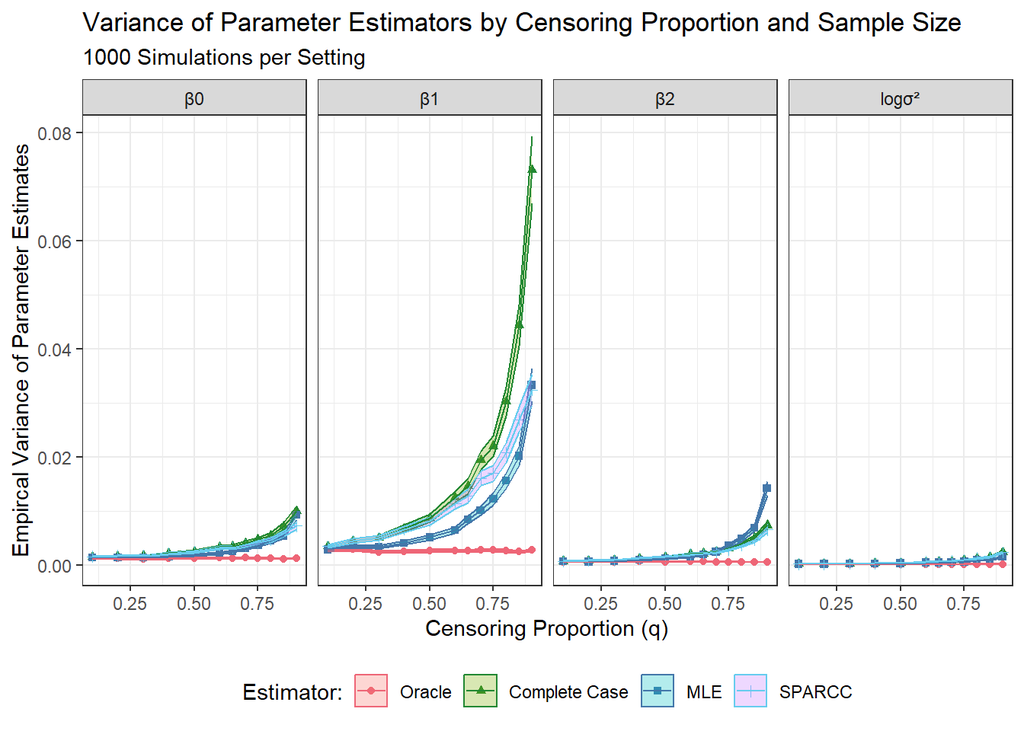

```r
# plot variance over q
ggplot(filter(sim.out.sum,
              n == 8000),
       aes(x = q,
           y = Var,
           ymin = Var.lower,
           ymax = Var.upper,
           fill = method,
           color = method,
           shape = method)) +
  geom_point() +
  geom_ribbon(alpha = 0.3) +
  geom_line() +
  facet_grid(~ param,
             scales = "free",
             labeller = labeller(param = param.labs)) +
  theme_bw() +
  theme(legend.position = "bottom") +
  scale_color_manual(values = pal_light[c(1, 2, 3, 5)]) +
  labs(x = "Censoring Proportion (q)",
       y = "Empircal Variance of Parameter Estimates",
       color = "Estimator:",
       shape = "Estimator:",
       fill = "Estimator:") +
  ggtitle("Variance of Parameter Estimators by Censoring Proportion and Sample Size",
          subtitle = paste0(n.rep, " Simulations per Setting"))
```

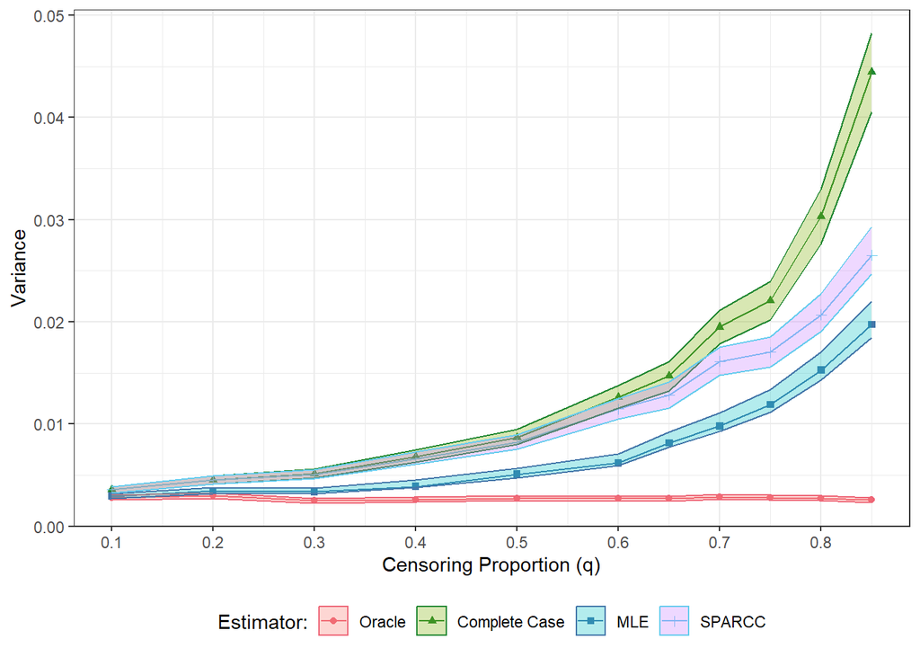

```r
# plot variance over q for beta_1 only and n = 8000
ggplot(filter(sim.out.sum,
              param == 2,
              q <= 0.85,
              n == 8000),
       aes(x = q,
           y = var,
           ymin = Var.lower,
           ymax = Var.upper,
           fill = method,
           color = method,
           shape = method)) +
  geom_point() +
  geom_line() +
  geom_ribbon(alpha = 0.3) +
  labs(x = "Censoring Proportion (q)",
       y = "Variance",
       color = "Estimator:",
       shape = "Estimator:",
       fill = "Estimator:") +
  theme_bw() +
  theme(legend.position = "bottom") +
  scale_x_continuous(breaks = seq(0.1, 0.9, by = 0.1)) +
  scale_color_manual(values = pal_light[c(1, 2, 3, 5)])
```

```r
ggsave("sim_plots/sim1_2_variances.png",
       dpi = 300,
       width = 6,
       height = 4)
```